# Линейные модели

## Линейная регрессия

Задача прогноза вещественного признака по прочим признакам (задача восстановления регрессии) решается минимизацией квадратичной ошибки. Рассмотрим линейную регресси на примере листка ириса. Будем предсказывать длину листка по его ширине. x - ширина листа, y - длина листка.

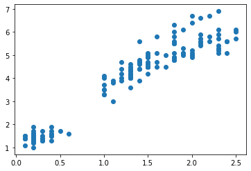

```python
from sklearn.datasets import load_iris
import numpy as np
import matplotlib.pyplot as plt
%matplotlib inline

data = load_iris().data
x = data[:,3]
y = data[:,2]
plt.scatter(x, y)
# plt.show()
```

```python
x
```

```
array([0.2, 0.2, 0.2, 0.2, 0.2, 0.4, 0.3, 0.2, 0.2, 0.1, 0.2, 0.2, 0.1,
       0.1, 0.2, 0.4, 0.4, 0.3, 0.3, 0.3, 0.2, 0.4, 0.2, 0.5, 0.2, 0.2,
       0.4, 0.2, 0.2, 0.2, 0.2, 0.4, 0.1, 0.2, 0.2, 0.2, 0.2, 0.1, 0.2,
       0.2, 0.3, 0.3, 0.2, 0.6, 0.4, 0.3, 0.2, 0.2, 0.2, 0.2, 1.4, 1.5,
       1.5, 1.3, 1.5, 1.3, 1.6, 1. , 1.3, 1.4, 1. , 1.5, 1. , 1.4, 1.3,
       1.4, 1.5, 1. , 1.5, 1.1, 1.8, 1.3, 1.5, 1.2, 1.3, 1.4, 1.4, 1.7,
       1.5, 1. , 1.1, 1. , 1.2, 1.6, 1.5, 1.6, 1.5, 1.3, 1.3, 1.3, 1.2,
       1.4, 1.2, 1. , 1.3, 1.2, 1.3, 1.3, 1.1, 1.3, 2.5, 1.9, 2.1, 1.8,
       2.2, 2.1, 1.7, 1.8, 1.8, 2.5, 2. , 1.9, 2.1, 2. , 2.4, 2.3, 1.8,
       2.2, 2.3, 1.5, 2.3, 2. , 2. , 1.8, 2.1, 1.8, 1.8, 1.8, 2.1, 1.6,
       1.9, 2. , 2.2, 1.5, 1.4, 2.3, 2.4, 1.8, 1.8, 2.1, 2.4, 2.3, 1.9,
       2.3, 2.5, 2.3, 1.9, 2. , 2.3, 1.8])
```

Напишите функцию, которая по двум параметрам $w_0$ и $w_1$ вычисляет квадратичную ошибку приближения зависимости длины листа $y$ от ширины листа $x$ прямой линией $y = w_0 + w_1 * x$:

$$E(w_0, w_1) = \frac{1}{n}\sum_{i=1}^n {(y_i - (w_0 + w_1 \cdot x_i))}^2 $$

Здесь $n$ – число наблюдений в наборе данных, $y_i$ и $x_i$ – длина и ширина листа ириса для $i$-ого объекта в наборе данных.

```python
def square_error(w0, w1):
    E = 0.0
    for i in range(len(x)):
        E += (y[i] - (w0+w1*x[i]))**2
    E2 = E/len(data)
    return E2
```

Возьмите параметры $\omega_0$ - свободный член и $\omega_1$ - наклон прямой и постройте две любые прямые, которые быдут некоторым образом описывать зависмость длины листа от его ширины. Представьте графически.

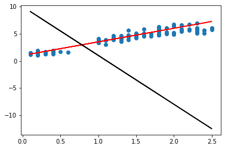

```python
w0 = 1
w1 = 2.5
W0 = 10
W1 = -9
lineFunc1 =  [w0 + w1 * x for x in x]
lineFunc2 =  [W0 + W1 * x for x in x]
plt.scatter(x, y)
plt.plot(x,lineFunc1, color='r')
plt.plot(x,lineFunc2, color = 'black')
```

Минимизация квадратичной функции ошибки - относительная простая задача, поскольку функция выпуклая. Для такой задачи существует много методов оптимизации. Рассмотрим, как функция ошибки зависит от одного параметра (наклон прямой), если второй параметр (свободный член) зафиксировать.

Постройте график зависимости функции ошибки от параметра $w_1$ при $w_0$ = 0.

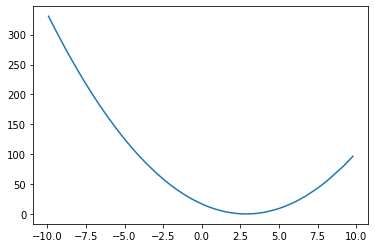

```python
w0 = 0.0
import random
w1 = [random.uniform(-10,10) for k in range(100)]
w1.sort()
Error_func = np.zeros(len(w1))
for j in range(len(w1)):
    Error_func[j] = square_error(w0,w1[j])
plt.plot(w1, Error_func)
```

[output not shown]

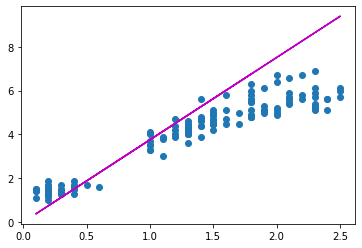

```python
from scipy.optimize import  minimize_scalar
w1_opt = minimize_scalar(square_error, args = w0, bounds = (-10,10)).x
opt = [w0 + w1_opt * x for x in x]
plt.scatter(x, y)
plt.plot(x,opt, 'm')
w1_opt
```

## Линейная классификация

Рассмотрим в работе способы построения линейной модели классификации.

Линейный классификатор представляет собой линейную модель, разделяющую два класса (-1, 1). Линейная модель описывается следующей формулой $\langle \omega, x \rangle + b = y$. Вектор весов $\omega$ - вектор нормали этой линейно модели. При $y = 0$, все точки $x$ принадлежат этой разделяющей прямой, при $y > 0$ объеты $x$ лежат с той стороны прямой линии, куда смотрит вектор весов $\omega$, при $y < 0$ с другой стороны прямой линии. Таким образом линейная модель разделяет все объекты на положительный и отрицательные, причем чем дальше объект лежит от прямой, тем большее абсолютное значение он имеет.

Необходимо ввести обозначение отступа:

$$M = y \langle \omega, x \rangle$$

Таким образом, если объект будет лежать со стороны своего класса (классифицироваться правильно), то $M$ всегда будет иметь положительное значение. В случае неправилной классификации отступ будет отрицательным.

Введем несколько loss-функцию, которые будет оптимизировать:

1. логистическая: $$\bar L(M) = \ln(1+ \exp(-M))$$
2. экспоненциальны: $$\bar L(M) = \exp(-M)$$
3. кусочно-линейная: $$\bar L(M) = max(0, 1-M))$$

Таким образом для каждого объекта будет вычислена его собственный штраф. Чтобы получить полную функцию потеря - просто проссумируем штрафы всех объектов. Таким образом у нас будет функция, подсчитывающая штрафы для конкретной модели. Необходимо ее оптимизировать, для этого надо вычислить градиент и начать движение (изменение весов модели $\omega$) в сторону антиградиента с некоторым постоянным шагом.

## Задача

1. Написать функцию расчета функции потерь (loss-функции) и градиента функции. (выбрать любую функцию)
2. Реализовать градиентный спуск по всем данным.
3. Реализовать стохастический градиентный спуск.

```python
from sklearn.datasets import make_blobs
import matplotlib.pyplot as plt
import numpy as np
%matplotlib inline
```

### Задача 1

Напишите две функции, которые будут получать на вход вектор весов, признаки и целевую переменную. Функции должны возвращать суммарную ошибку и градиент.

```python
def loss(c_w0, c_w1, c_w2, x, y):
    return np.sum(np.exp(-y * (c_w2 * x[:,1] + c_w1 * x[:,0] + c_w0)))

def grad_loss(c_w0, c_w1, c_w2, x, y):
    df_w0 = np.sum(-y * np.exp(-y * (c_w2 * x[:,1] + c_w1 * x[:,0] + c_w0)))
    df_w1 = np.sum(-y * x[:,0] * np.exp(-y * (c_w2 * x[:,1] + c_w1 * x[:,0] + c_w0)))
    df_w2 = np.sum(-y * x[:,1] * np.exp(-y * (c_w2 * x[:,1] + c_w1 * x[:,0] + c_w0)))
    return df_w0, df_w1, df_w2
```

Дан набор данных. Проведена нормализация данных по признакам и выставлены классы (-1, 1).

Проведите случайную линейную модель, постройте ее на графике и вычислите для нее суммарную функцию ошибки. Проверьте, что суммарная функция ошибки считается правильно.

```python
X, Y = make_blobs(n_samples=100, n_features=2, centers=2 ,cluster_std=1, random_state=17, center_box=(-10, 10))
cmap = plt.cm.coolwarm
plt.figure(figsize=(10,10))
X[:,0] = 2 * (X[:,0] - X[:,0].min()) / (X[:,0].max() - X[:,0].min()) - 1
X[:,1] = 2 * (X[:,1] - X[:,1].min()) / (X[:,1].max() - X[:,1].min()) - 1
Y[Y == 0] = -1 #Нормализация классов 0 и 1 на -1 и 1
step = 1e-3
```

```python
def classificator(w0,w1,w2,x):
    return w2 * x[:,1] + w1 * x[:,0] + w0
```

[figure not shown]

```python
from matplotlib.animation import FuncAnimation
from IPython.display import HTML
from matplotlib import animation, rc
from celluloid import Camera

w0 = np.random.random()
w1 = np.random.random()
w2 = np.random.random()

#Использована библиотека celluloid (убрали функцию update и заменили ее циклом)
fig, ax = plt.subplots()
camera = Camera(fig)
x1,x2 = np.mgrid[min(X[:,0]) - 0.2:max(X[:,0]) + 0.2:0.1,
                min(X[:,1]) - 0.2:max(X[:,1]) + 0.2:0.1]

for i in range(150):
    global X, Y, step, w0, w1, w2, x1, x2
    #print(loss(w0,w1,w2,X,Y))
    #print(w0,w1,w2)
    y = classificator(w0,w1,w2, np.concatenate((np.expand_dims(x1.ravel(), axis = -1), x2.reshape((-1,1))), axis = 1))
    y = y.reshape(x1.shape)
    plt.contourf(x1, x2, y, cmap=plt.cm.coolwarm)
    plt.scatter(X[:,0], X[:,1], s = 200, c = Y, cmap=cmap)
    plt.text(-1.1, 0.75, r'loss = {0:.5f}'.format(loss(w0,w1,w2,X,Y)) ) #Подпись со значениями лосс-функции
    Dw0, Dw1, Dw2 = grad_loss(w0,w1,w2,X,Y)
    w0 -= step * Dw0
    w1 -= step * Dw1
    w2 -= step * Dw2
    camera.snap() #Снимок фигуры на каждом повторении цикла

plt.colorbar()
anim = camera.animate() #Склеивание кадров в гифку
anim.save('grad_descent.gif', writer='imagemagick')
```

```python
anim
```

[video not shown]

### Задача 2. Реализация стохастического градиентного спуска.

Используйте на каждой итерации не весь набор данных, а $n$ случайных объектов из выборки. Оформите результат схождения вашей модели в виде гифки.

[figure not shown]

```python
fig2, ax = plt.subplots()
x01,x02 = np.mgrid[min(X[:,0]) - 0.2:max(X[:,0]) + 0.2:0.1,
                min(X[:,1]) - 0.2:max(X[:,1]) + 0.2:0.1]
X0 = np.array([[0.0] * 2 for i in range(35)])
w00 = np.random.random()
w01 = np.random.random()
w02 = np.random.random()
camera2 = Camera(fig2)
for i in range(150):
    global X, Y, step, w00, w01, w02, x01, x02, X0, Y0
    tmp = [0 for i in range(35)] #Выбираем 35 рандомных чисел - они будут индексами для отбора Х
    for i in range(35):
        p = np.random.randint(0, 100)
        while p in tmp:
            p = np.random.randint(0, 100)
        tmp[i] = p
    j = 0
    for i in tmp: #Заполняем пустой массив значениями Х по рандомным индексам
        X0[j, 0] = X[i, 0]
        X0[j, 1] = X[i, 1]
        j+= 1
    Y0 = np.array([Y[i] for i in tmp])
    y0 = classificator(w00,w01,w02, np.concatenate((np.expand_dims(x01.ravel(), axis = -1), x02.reshape((-1,1))), axis = 1))
    y0 = y0.reshape(x01.shape)
    plt.contourf(x01, x02, y0, cmap=plt.cm.coolwarm)
    plt.scatter(X[:,0], X[:,1], s = 200, c = Y, cmap=cmap)
    plt.text(-1.1, 0.75, r'loss = {0:.5f}'.format(loss(w00,w01,w02,X0,Y0)) )
    Dw00, Dw01, Dw02 = grad_loss(w00,w01,w02,X0,Y0)
    w00 -= step * Dw00
    w01 -= step * Dw01
    w02 -= step * Dw02
    camera2.snap()

plt.colorbar()
anim2 = camera2.animate()
anim2.save('grad_descent2.gif', writer='imagemagick')
```

```python
anim2
```

[video not shown]